# Project Assignment : Exercise Quality Predictor

### Executive summary

Using devices such as *Jawbone Up*, *Nike FuelBand* and *Fitbit* it is now possible to collect a large amount of data about personal activity relatively inexpensively.

One thing that people regularly do is quantify how much of a particular activity they do, but they rarely quantify how well they do it.

In this project we aim to use the *Weight Lifting Exercise Dataset*, containing data from accelerometers on the belt, forearm, arm, and dumbell of 6 participants. Participants were asked to perform barbell lifts correctly and incorrectly in 5 different ways.

We aim to design a prediction algorithm to correctly predict the quality of exercises defined by the variable “classe”.

This data is courtesy of http://groupware.les.inf.puc-rio.br/har (see the section on the Weight Lifting Exercise Dataset).

### Introduction

We start by identifying whether files were already downloaded from the internet, downloading them if this is not the case, and loading the data into R.

```r
library(dplyr)
library(caret)

knitr::opts_chunk$set(cache = TRUE, warning = FALSE)

setwd("~/Documents/Courses/Data specialization Johns Hopkins/08_Practical Machine Learning/project/")
if(!dir.exists("data")) dir.create("data")
setwd("data")
if(!file.exists("pml-training.csv")) download.file("https://d396qusza40orc.cloudfront.net/predmachlearn/pml-training.csv", "pml-training.csv")
if(!file.exists("test_cases.csv")) download.file("https://d396qusza40orc.cloudfront.net/predmachlearn/pml-testing.csv", "test_cases.csv")

pml_training <- read.csv("pml-training.csv")
test_cases <- read.csv("test_cases.csv")
```

### Exploring the data

#### Variables

The outcome “classe” is categorical with 5 potential outcomes A to E. Distributions of outcomes are roughly equal, only classe A is more frequent than other outcomes. There is a large number of variables. Variables 1-7 seem trivial to the outcome.

```r
ncol(pml_training)
```

```
## [1] 160
```

```r
names(pml_training)
```

```
##   [1] "X"                        "user_name"
##   [3] "raw_timestamp_part_1"     "raw_timestamp_part_2"
##   [5] "cvtd_timestamp"           "new_window"
##   [7] "num_window"               "roll_belt"
##   [9] "pitch_belt"               "yaw_belt"
##  [11] "total_accel_belt"         "kurtosis_roll_belt"
##  [13] "kurtosis_picth_belt"      "kurtosis_yaw_belt"
##  [15] "skewness_roll_belt"       "skewness_roll_belt.1"
##  [17] "skewness_yaw_belt"        "max_roll_belt"
##  [19] "max_picth_belt"           "max_yaw_belt"
##  [21] "min_roll_belt"            "min_pitch_belt"
##  [23] "min_yaw_belt"             "amplitude_roll_belt"
##  [25] "amplitude_pitch_belt"     "amplitude_yaw_belt"
##  [27] "var_total_accel_belt"     "avg_roll_belt"
##  [29] "stddev_roll_belt"         "var_roll_belt"
```

[output cut: 65 more lines]

```r
dplyr::count(pml_training, classe)
```

```
## # A tibble: 5 x 2
##   classe     n
##   <fctr> <int>
## 1      A  5580
## 2      B  3797
## 3      C  3422
## 4      D  3216
## 5      E  3607
```

#### Correlations

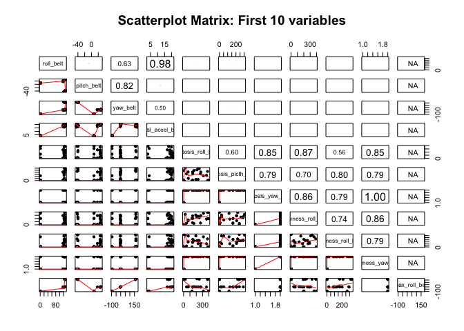

```r
panel.cor <- function(x, y, digits=2, prefix="", cex.cor, ...)
{
    usr <- par("usr"); on.exit(par(usr))
    par(usr = c(0, 1, 0, 1))
    r <- abs(cor(x, y))
    txt <- format(c(r, 0.123456789), digits=digits)[1]
    txt <- paste(prefix, txt, sep="")
    if(missing(cex.cor)) cex.cor <- 0.8/strwidth(txt)
    text(0.5, 0.5, txt, cex = cex.cor * r)
}

pairs(~ ., data = pml_training[1:1000, 8:18],
      lower.panel=panel.smooth, upper.panel=panel.cor,
      pch=20, main="Scatterplot Matrix: First 10 variables")
```

#### Q-Q plots

We also create a QQ-plot for 3 selected variables just to explore what those variables look like.

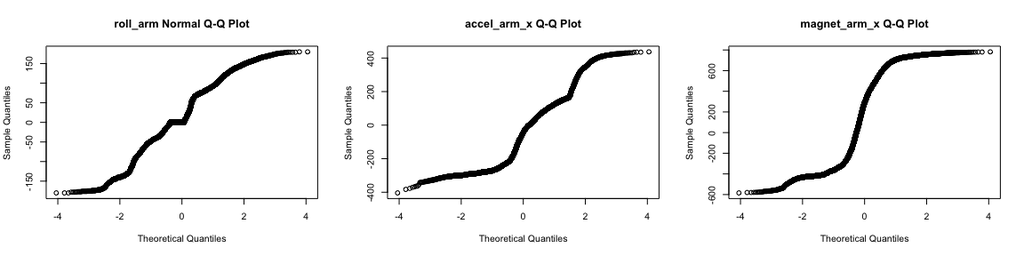

```r
#do a series of QQ tables here
par(mfrow = c(1, 3))
qqnorm(pml_training$roll_arm, main = "roll_arm Normal Q-Q Plot")
qqnorm(pml_training$accel_arm_x, main = "accel_arm_x Q-Q Plot")
qqnorm(pml_training$magnet_arm_x, main = "magnet_arm_x Q-Q Plot")
```

We make the following observations about the predictors based on our explorations: - There is a large number of predictors - There is colinearity between predictors - predictors are not all normally distributed - There is a large number of NA predictor values

We decide on the following options for prediction training - centering and scaling is indicated to normalize data - we want to try out preprocessing with PCA to account for colinearity and dimension reduction - we want to deal with the large amounts of NA values

### Data slicing

We use the caret package to do some preprocessing to our data. First of all we remove variables 1 to 7 which are trivial. We make all data numerical except for the outcome. We then slice the pml_training set into separate training (75%) and testing (25%) fractions, following the advice given during the course to use these relative sizes in large datasets. From this point on all transformations are performed on the training set, and then in the same fashion on the testing set.

```r
set.seed(123)

pml_training <- pml_training[, 8:160]
for(i in 1:152) pml_training[,i] <- as.numeric(as.character(pml_training[,i]))
index <- createDataPartition(y = pml_training$classe, p = .75, list = FALSE)

training <- pml_training[index, ]
testing <- pml_training[-index, ]
```

### Preprocessing part 1

We check which parameters have near zero variance and exclude those. To explore the amount of NA values in variables we then run a function that returns 0 if a variable does not have NAs and that returns the ratio of NA values to non NA values in the variable if any NA values are present.

```r
set.seed(234)

nzv <- nearZeroVar(training, saveMetrics = TRUE)
training <- training[, which(nzv$nzv == FALSE)]
testing <- testing[, which(nzv$nzv == FALSE)]

NA_ratios <- apply(training, 2, function(x) {
  if(any(is.na(x)) == FALSE) {
    return(0)
  } else {
    return((length(x[which(is.na(x))])/length(x[which(!is.na(x))])))
  }
})

NA_ratios
```

```
##                roll_belt               pitch_belt                 yaw_belt
##                  0.00000                  0.00000                  0.00000
##         total_accel_belt       kurtosis_roll_belt      kurtosis_picth_belt
##                  0.00000                 47.09804                 49.92734
##       skewness_roll_belt     skewness_roll_belt.1            max_roll_belt
##                 46.94137                 49.92734                 46.02236
##           max_picth_belt             max_yaw_belt            min_roll_belt
##                 46.02236                 47.09804                 46.02236
##           min_pitch_belt             min_yaw_belt      amplitude_roll_belt
##                 46.02236                 47.09804                 46.02236
##     amplitude_pitch_belt     var_total_accel_belt            avg_roll_belt
##                 46.02236                 46.02236                 46.02236
##         stddev_roll_belt            var_roll_belt           avg_pitch_belt
##                 46.02236                 46.02236                 46.02236
##        stddev_pitch_belt           var_pitch_belt             avg_yaw_belt
##                 46.02236                 46.02236                 46.02236
##          stddev_yaw_belt             var_yaw_belt             gyros_belt_x
##                 46.02236                 46.02236                  0.00000
##             gyros_belt_y             gyros_belt_z             accel_belt_x
##                  0.00000                  0.00000                  0.00000
##             accel_belt_y             accel_belt_z            magnet_belt_x
##                  0.00000                  0.00000                  0.00000
##            magnet_belt_y            magnet_belt_z                 roll_arm
##                  0.00000                  0.00000                  0.00000
##                pitch_arm                  yaw_arm          total_accel_arm
##                  0.00000                  0.00000                  0.00000
##            var_accel_arm              gyros_arm_x              gyros_arm_y
##                 46.02236                  0.00000                  0.00000
##              gyros_arm_z              accel_arm_x              accel_arm_y
##                  0.00000                  0.00000                  0.00000
##              accel_arm_z             magnet_arm_x             magnet_arm_y
##                  0.00000                  0.00000                  0.00000
##             magnet_arm_z        kurtosis_roll_arm       kurtosis_picth_arm
##                  0.00000                 57.40476                 57.63745
##         kurtosis_yaw_arm        skewness_roll_arm       skewness_pitch_arm
##                 47.25574                 57.17391                 57.63745
##         skewness_yaw_arm            max_picth_arm              max_yaw_arm
##                 47.25574                 46.02236                 46.02236
##              min_yaw_arm        amplitude_yaw_arm            roll_dumbbell
##                 46.02236                 46.02236                  0.00000
```

[output cut: 25 more lines]

```
##                  0.00000                 58.82927                 59.07347
##    skewness_roll_forearm   skewness_pitch_forearm        max_picth_forearm
##                 58.58704                 59.07347                 46.02236
##          max_yaw_forearm        min_pitch_forearm          min_yaw_forearm
##                 58.82927                 46.02236                 58.82927
##   amplitude_roll_forearm  amplitude_pitch_forearm      total_accel_forearm
##                 46.02236                 46.02236                  0.00000
##        var_accel_forearm          gyros_forearm_x          gyros_forearm_y
##                 46.02236                  0.00000                  0.00000
##          gyros_forearm_z          accel_forearm_x          accel_forearm_y
##                  0.00000                  0.00000                  0.00000
##          accel_forearm_z         magnet_forearm_x         magnet_forearm_y
##                  0.00000                  0.00000                  0.00000
##         magnet_forearm_z                   classe
##                  0.00000                  0.00000
```

```r
training <- training[, which(NA_ratios == 0)]
testing <- testing[, which(NA_ratios == 0)]
```

First we see that after leaving out variables with near zero variance 120 variables (including outcome) remain. Importantly, the outcome did not have near zero variance. If this were not the case we would have accidentally filtered out our outcome variable. It is clear that we still have a large amount of remaining variables, and that numbers of NA values in this set are high. We find that 53 variables (including the outcome) do not contain NA values. We also find that other variables all have >46 times as many NA values than non-NA values.

Taking into account the large number of variables in the set, and the high ratio of NA values in a large number of variables, we decide not to impute the NA values but to fully exclude all variables holding NA values.

### Preprocessing part 2

We perform preprocessing by centering and scaling all data (as we have oberved before that data was not normally distributed). We perform a principal component analysis (PCA) to see whether we can perform dimension reduction without sacrificing too much accuracy in this fashion.

```r
set.seed(345)

training_ppvalues <- preProcess(training[,-53], method = c("center", "scale"))
training_pp <- predict(training_ppvalues, training)
testing_pp <- predict(training_ppvalues, testing)

training_pp_PCA <- preProcess(training_pp[, -53], method="pca", pcaComp=9)
PCs <- cbind(predict(training_pp_PCA, training_pp[, -53]), classe = training_pp[, 53])
```

### Training part 1: Linear Discriminant Analysis (LDA) with and without PCA

```r
set.seed(456)

fit_lda <- train(classe ~ .,
                    data = training_pp,
                    method = "lda",
                    verbose = FALSE)

fit_lda_pca <- train(classe ~ .,
                    data = PCs,
                    method = "lda",
                    verbose = FALSE)

training_preds_lda <- predict(fit_lda, training_pp)
training_preds_lda_pca <- predict(fit_lda_pca, PCs)

confusionMatrix(training_preds_lda, training[, 53])
```

```
## Confusion Matrix and Statistics
##
##           Reference
## Prediction    A    B    C    D    E
##          A 3440  455  281  153   96
##          B  102 1810  241   98  449
##          C  320  335 1680  271  251
##          D  308  107  301 1797  263
##          E   15  141   64   93 1647
##
## Overall Statistics
##
##                Accuracy : 0.7049
##                  95% CI : (0.6974, 0.7122)
##     No Information Rate : 0.2843
##     P-Value [Acc > NIR] : < 2.2e-16
##
##                   Kappa : 0.6263
##  Mcnemar's Test P-Value : < 2.2e-16
##
## Statistics by Class:
##
##                      Class: A Class: B Class: C Class: D Class: E
## Sensitivity            0.8220   0.6355   0.6545   0.7450   0.6086
## Specificity            0.9065   0.9250   0.9031   0.9204   0.9739
## Pos Pred Value         0.7774   0.6704   0.5880   0.6473   0.8403
## Neg Pred Value         0.9276   0.9136   0.9252   0.9485   0.9170
## Prevalence             0.2843   0.1935   0.1744   0.1639   0.1839
## Detection Rate         0.2337   0.1230   0.1141   0.1221   0.1119
## Detection Prevalence   0.3007   0.1834   0.1941   0.1886   0.1332
## Balanced Accuracy      0.8642   0.7803   0.7788   0.8327   0.7913
```

```r
confusionMatrix(training_preds_lda_pca, training[, 53])
```

```
## Confusion Matrix and Statistics
##
##           Reference
## Prediction    A    B    C    D    E
##          A 2782  761 1143  279  736
##          B  318  929  232  486  614
##          C  345  248  647  237  341
##          D  450  418  188 1064  353
##          E  290  492  357  346  662
##
## Overall Statistics
##
##                Accuracy : 0.4134
##                  95% CI : (0.4054, 0.4214)
##     No Information Rate : 0.2843
##     P-Value [Acc > NIR] : < 2.2e-16
##
##                   Kappa : 0.248
##  Mcnemar's Test P-Value : < 2.2e-16
##
## Statistics by Class:
##
##                      Class: A Class: B Class: C Class: D Class: E
## Sensitivity            0.6648  0.32619  0.25205  0.44113  0.24464
## Specificity            0.7229  0.86099  0.90363  0.88550  0.87637
## Pos Pred Value         0.4880  0.36022  0.35589  0.43025  0.30834
## Neg Pred Value         0.8444  0.84191  0.85116  0.88991  0.83740
## Prevalence             0.2843  0.19350  0.17441  0.16388  0.18386
## Detection Rate         0.1890  0.06312  0.04396  0.07229  0.04498
## Detection Prevalence   0.3873  0.17523  0.12352  0.16803  0.14588
## Balanced Accuracy      0.6938  0.59359  0.57784  0.66332  0.56051
```

We conclude that although these predictions are better than chance (Accuracy of ??0.2 with 5 categories), it is insufficient. We also note that PCA significantly does not improve the accuracy.

### Training part 2: Random Forest modeling

We decide to employ random forest modeling, which is a more powerful (and time consuming) algorithm. To make this analysis workable with limited processing time we perform them with a limited amount (= 100) of trees. We use all variables as input. We use 3-fold cross validation in order to decrease bias somewhat further, but use a low k in order to limit the computation time and because we are dealing with a large dataset.

```r
set.seed(567)

fit_rf <- train(classe ~ .,
                    data = training_pp,
                    method = "rf",
                    ntree = 100,
                    trControl=trainControl(method="cv",number=3),
                    verbose = TRUE)

training_pp_preds_rf <- predict(fit_rf, training_pp)
testing_pp_preds_rf <- predict(fit_rf, testing_pp)

confusionMatrix(training_pp_preds_rf, training[, 53])
```

```
## Confusion Matrix and Statistics
##
##           Reference
## Prediction    A    B    C    D    E
##          A 4185    0    0    0    0
##          B    0 2848    0    0    0
##          C    0    0 2567    0    0
##          D    0    0    0 2412    0
##          E    0    0    0    0 2706
##
## Overall Statistics
##
##                Accuracy : 1
##                  95% CI : (0.9997, 1)
##     No Information Rate : 0.2843
##     P-Value [Acc > NIR] : < 2.2e-16
##
##                   Kappa : 1
##  Mcnemar's Test P-Value : NA
##
## Statistics by Class:
##
##                      Class: A Class: B Class: C Class: D Class: E
## Sensitivity            1.0000   1.0000   1.0000   1.0000   1.0000
## Specificity            1.0000   1.0000   1.0000   1.0000   1.0000
## Pos Pred Value         1.0000   1.0000   1.0000   1.0000   1.0000
## Neg Pred Value         1.0000   1.0000   1.0000   1.0000   1.0000
## Prevalence             0.2843   0.1935   0.1744   0.1639   0.1839
## Detection Rate         0.2843   0.1935   0.1744   0.1639   0.1839
## Detection Prevalence   0.2843   0.1935   0.1744   0.1639   0.1839
## Balanced Accuracy      1.0000   1.0000   1.0000   1.0000   1.0000
```

```r
confusionMatrix(testing_pp_preds_rf, testing[, 53])
```

```
## Confusion Matrix and Statistics
##
##           Reference
## Prediction    A    B    C    D    E
##          A 1394    3    0    0    0
##          B    1  944    7    0    0
##          C    0    2  844    7    0
##          D    0    0    4  796    1
##          E    0    0    0    1  900
##
## Overall Statistics
##
##                Accuracy : 0.9947
##                  95% CI : (0.9922, 0.9965)
##     No Information Rate : 0.2845
##     P-Value [Acc > NIR] : < 2.2e-16
##
##                   Kappa : 0.9933
##  Mcnemar's Test P-Value : NA
##
## Statistics by Class:
##
##                      Class: A Class: B Class: C Class: D Class: E
## Sensitivity            0.9993   0.9947   0.9871   0.9900   0.9989
## Specificity            0.9991   0.9980   0.9978   0.9988   0.9998
## Pos Pred Value         0.9979   0.9916   0.9894   0.9938   0.9989
## Neg Pred Value         0.9997   0.9987   0.9973   0.9981   0.9998
## Prevalence             0.2845   0.1935   0.1743   0.1639   0.1837
## Detection Rate         0.2843   0.1925   0.1721   0.1623   0.1835
## Detection Prevalence   0.2849   0.1941   0.1739   0.1633   0.1837
## Balanced Accuracy      0.9992   0.9964   0.9925   0.9944   0.9993
```

We see that the Accuracy is 100% on the training set, and 99.5% on the testing set. 99.5% Accuracy on the testing set implies an out-of-sample error rate of 0.5%, which should indicate sufficient performance to predict the 20 test samples. We perform the preprocessing and prediction on the test cases below. Our prediction give us a score of 20/20 in the quiz.

### Prediction

```r
test_cases <- test_cases[, c(8:160)]
for(i in 1:152) test_cases[,i] <- as.numeric(as.character(test_cases[,i]))
test_cases <- test_cases[, which(nzv$nzv == FALSE)]
test_cases <- test_cases[, which(NA_ratios == 0)]
test_cases_pp <- predict(training_ppvalues, test_cases)


assignment_predictions <- cbind(cases = c(1:20), prediction =  as.character(predict(fit_rf, test_cases_pp)))

library(xtable)

print(xtable(assignment_predictions), type = "html", include.rownames = FALSE, width = 4)
```

| cases | prediction |
| --- | --- |
| 1 | B |
| 2 | A |
| 3 | B |
| 4 | A |
| 5 | A |
| 6 | E |
| 7 | D |
| 8 | B |
| 9 | A |
| 10 | A |
| 11 | B |
| 12 | C |
| 13 | B |
| 14 | A |
| 15 | E |
| 16 | E |
| 17 | A |
| 18 | B |
| 19 | B |
| 20 | B |

### Conclusion

In this assignment we used random forest modelling to predict the fashion in which a weight lifting exercise was performed using biometric measurements collected during the exercise. We show that in this fashion we were able to generate a highly accurate model that accurately predicted a number of test cases.